# Principios básicos del diseño de experimentos

En un experimento, el experimentador cambia al menos una de las variables bajo estudio y luego observa el efecto de sus acciones. Lo que hace un experimento especial es el *control* que tiene el experimentador para asignar *tratamientos* a las *unidades experimentales*. Mientras que en estudios obsevacionales se observan que unidades están asignadas a cierto tratamiento, pero la asignación de estas unidades a los tratamientos no se puede controlar.

> El **diseño de experimentos** es la manera en la que la aleatorización de las unidades experimentales es es llevada a cabo y cómo los datos son recolectados. La estructura del error de un experimento es una consecuencia del diseño del experimento.

Un experimento tiene tratamientos, unidades experimentales, respuestas, y un método de asignar los tratamientos a las unidades. Pero, no incluye el método para analizar los resultados. Sin embargo, el diseño y análisis de un experimento están interalacionados y necesitan ser estudiados lado a lado. Más precisamente, cuando se diseña un experimento, se debe teer en cuenta el análisis que se va a llevar a cabo. Igualmente, la eficiencia del análisis dependerá del diseño experimental particular usado para recolectar los datos. Por esta razón, en este curso se estudian ambas componentes.

## Terminología

#### Tratamientos

Los procedimientos de los que se quiere aprender o comparar. Por ejemplo, diferentes clases de fertilizantes en agronomia o diferente temperaturas en un reactor en ingeniería química.

#### Unidades experimentales

Los elementos (animal, planta u objeto) a los que los tratamientos son aplicados.

#### Factor

variable independiente manipulada por el experimentador. Cada factor tiene dos o más niveles y la combinación de niveles de varios factores forman un tratamiento.

#### Respuestas

las medidas usadas para juzgar que hacen los tratamientos.

#### Error experimental

la variación en las respuestas (que son modeladas como aleatorias).

#### Tratamiento control

un tratamiento estándar o base.

#### Placebo

Un tratamiento “nulo” usado cómo un caso especial de control. Placebos son frecuentemente usados cuando las unidades muestrales son humanos, porque la gente tiende a responder a culaquier tratamiento.

#### Cegamiento

El experimentador y/o los individuos humanos no saben el tratamiento que les ha sido asignado.

#### Confusión

cuando el efecto de un factor no puede ser distinguido del efecto de otro factor.

## Técnicas básicas

Las técnicas fundamentales del diseño experimental son replicación, bloqueo, y aleatorización. Las dos primeras ayudan a incrementar la precisión en el experimento; la última es usada para reducir sesgo. Estas técnicas son definidas a continuación.

#### Replicación

repeticiones independientes de cada tratamiento. Hay una diferencia importante entre “replicación”” y “medida repetidas.” Suponga que cuatro sujetos son asignados a un tratamiento y una medida es tomada en cada sujeto. El resultado son cuatro observaciones independientes, ósea cuatro replicaciones. Pero si un sujeto es asignado a un tratamiento y se hacen cuatro medidas del mismo sujeto, las medidas no son independientes. Estas últimas son medidas repetidas.

#### Bloqueo

es una técnica usada para mejorar la precisión con la que se hacen comparaciones entre factores de interes. Es común usar bloqueo para eliminar o reducir la variabilidad producida por factores que pueden influenciar la respuesta, pero no son de interes.

#### Aleatorización

Uso de un mecanísmo probabilístico para asignar tratamientos a las unidades experimentales.

```
Suponga que se quieren asignar $n=8$ unidades experimentales a tres tratamientos, $t = 3$. El tratamiento 1 y 3 va a ser aplicado a 3 unidades cada uno y el tratamiento 2 va a ser aplicado a 2 unidades. Se puede usar el siguiente código en R para asignar las unidades a los tratamientos:
```

```r
n_i  <- c(3,2,3); t <- length(n_i); n <- sum(n_i)
trat <- rep(1:t, times = n_i)
trat[order(runif(n))]
```

```
## [1] 3 1 2 1 3 1 2 3
```

## Planeación de experimentos

La planeación de un experimento requiere bastante tiempo. Por esto, en la práctica el experimentador es tentado a iniciar la recolección de datos sin pensar lo suficiente en el diseño experimental. Luego es el caso que los datos recolectados no permitan un buen análisis. La siguiente lista sumariza las decisiones que se deden tomar en el proceso de planeación de un experimento.

Los pasos en ésta lista no son independientes y es frecuentemente necesario volver y revisar decisiones de diseño hechas anteriormente.

1. Definir el objetivo del experimento. Es necesario saber las preguntas que se quieren responder usando el experimento.
2. Identificar las fuentes de variación, incluyendo tratamientos, unidades experimentales, y factores de bloqueo.
3. Seleccionar la manera de asignar las unidades experimentales a los tratamientos. La determinación de cúal diseño es usado depende de los objetivos de la investigación y de las unidades experimentales.
4. Especificar que respuesta se va a medir.
5. Hacer un estudio piloto.
6. Especificar el modelo.
7. Dados los pasos 1, 3, y 6, esbozar el análisis estadístico.
8. Calcular el número de observaciones que necesitan ser tomadas.

## Diseños Completamente Aleatorizados con un factor

#### Ejemplo – Stability of a fluorescent reagent

> The following table shows the results obtained in an investigation into the stability of a fluorescent reagent stored under different conditions. The values given are the fluorescence signals (in arbitrary units) from dilute solutions of equal concentration. Three replicate measurements were made on each sample.

| Conditions | Replicate measurements |
| --- | --- |
| A Freshly prepared | 102, 100, 101 |
| B Stored for 1 hour in the dark | 101, 101, 104 |
| C Stored for 1 hour in subdued light | 97, 95, 99 |
| D Stored for 1 hour in bright light | 90, 92, 94 |

> **Fuente**: Miller J. and Miller J. (2010). Statistics and Chemometrics for Analytical Chemistry. Prentice Hall

```r
fluorescent <- data.frame( y =c(102, 100, 101, 101, 101, 104, 97, 95, 99, 90, 92, 94),
                           storage = gl(n = 4, k = 3, labels = c("A","B","C","D")))

library(tidyverse, warn.conflicts = FALSE)
```

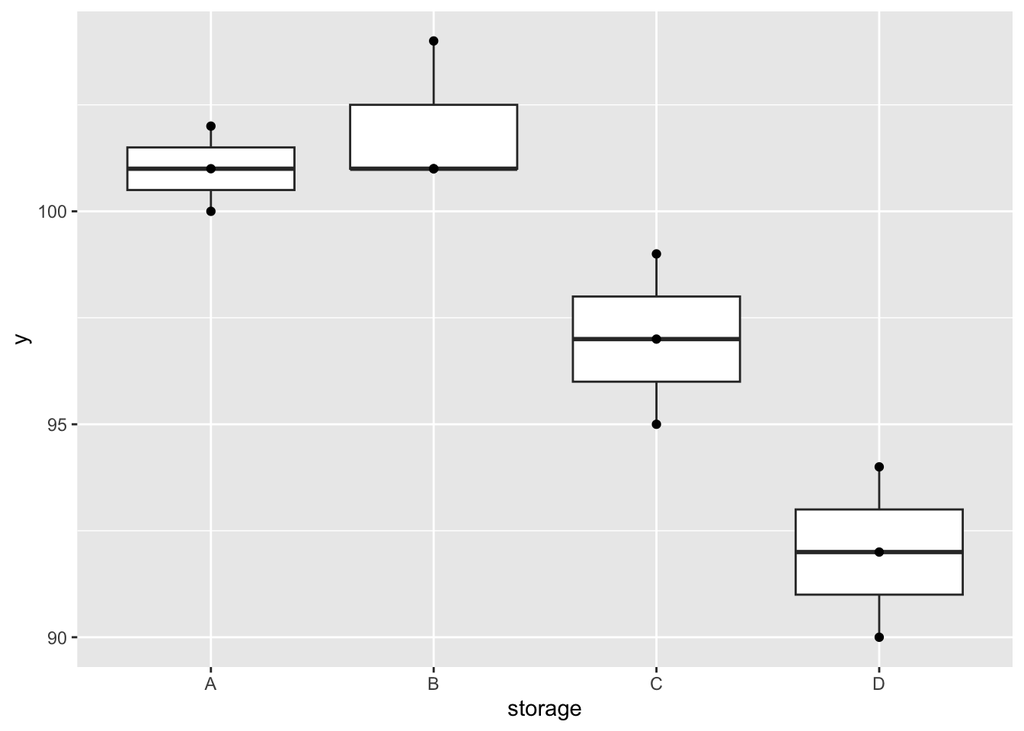

```r
ggplot(fluorescent, aes(x = storage, y)) +
  geom_boxplot()+
  geom_point()
```

Un diseño es la regla que determina la asignación de unidades experimentales a tratamientos. El diseño más simple es el diseño completamente aleatorizado (DCA), donde las unidades experimentales son asignadas a los tratamientos completamente aleatorizadas. La única restricción es el número de observaciones que deben ser asignadas a cada tratamiento.

Sea $n_i$ el número de observaciones que seran medidas en el $i$-ésimo tratamiento, $i=1,2,\ldots, t$ donde $t$ el número de tratamientos. El número total de observaciones es denotado por $n = \displaystyle\sum_{i=1}^tn_i.$ Cómo obtener el tamaño de muestra $n_i$ se discute en luego en el curso.

Sea $Y_{it}$ una variable aleatoria que representa la respuesta obtenida en la $j$-ésima observación del $i$-ésimo tratamiento. Denótese el parámetro de la respuesta, en las mismas condiciones experimentales y sin ruido, al $i$-ésimo tratamiento por $\mu_i$. Fuentes de variación que son vistas como menores e ignoradas durante el proceso de planeación del experimento tambíen contribuyen a la variación en la variable respuesta. Estas fuentes de variación son representadas por una sola variable aleatoria de media zero $\epsilon_{ij}$, llamada *error*.

## Modelo para un diseño completamente aleatorizado

El modelo es entonces

$$Y_{ij} = \mu_i + \epsilon_{ij},
\qquad\qquad j = 1, \ldots, n_i, \qquad i = 1,\ldots, t,$$

donde $t$ es el número de tratamientos y $n_i$ es el número de observaciones a ser tomadas con el $i$-ésimo tratamiento. Una alternativa para escribir este modelo es reeemplazar el parámetro $\mu_i$ por $\mu+\tau_i$, luego el modelo se convierte en

$$Y_{ij} = \mu +\tau_i + \epsilon_{ij},
\qquad\qquad j = 1, \ldots, n_i, \qquad i = 1,\ldots, t.$$

En este parametrización del modelo original, $\mu+\tau_i$ denota la media verdadera de la respuesta para el $i$-ésimo tratamiento. El parámetro $\mu$ es una constante, y el parámetro $\tau_i$ representa la desviación positiva o negativa de la respuesta a esta constante cuando el $i$-ésimo tratamento es observado. Ésta desviación es llamada el *efecto* del $i$-ésimo tratamiento en la respuesta. A este modelo se le llama el modelo de efectos.

Las variables error representan todas las pequeñas fuentes de variación juntas, incluyendo todos los errores de medición. En estas notas se asume que las variables error son independientes y tienen una distribución normal con media cero y varianza $\sigma^2$, que es desconocida y debe ser estimada. Estos supuestos son llamados los supuestos sobre error.

Con este supuesto podemos escribir el modelo para el diseño completamente aleatorizado con $t$ tratamientos y efectos fijos como:

$$Y_{ij} = \mu_i + \epsilon_{ij},
\qquad\epsilon_{ij}\sim N(0,\sigma^2),\qquad j = 1, \ldots, n_i, \qquad
i = 1,\ldots, t,$$

donde los errores son mutualmente independientes. A este modelo se le llama el modelo de celdas medias.

Note que $Y_{ij} \sim N( \mu_i, \sigma^2)$ y como los $\epsilon_{ij}$ son mutualmente independientes, las $Y_{ij}$ tambíen lo son. La media muestral para el $i$-ésimo tratamiento es

$$\bar{y}_{i\cdot} =
\frac{1}{n_i}\sum_{j=1}^{n_i}y_{ij}$$

y la media global es dada por

$$\bar{y}_{\cdot\cdot} =
\frac{1}{t}\sum_{i=1}^t\hat{y}_{i\cdot} =
\frac1{n}\sum_{i=1}^t\sum_{j=1}^{n_i}y_{ij}$$

#### Sumas de cuadrados

Sea $SST, SSR$ y $SSE$ respectivamente la variación total en $Y$, la variación explicada por el modelo ajustado, y la variación no explicada (o residual). Se define estas sumas de cuadrados por

$$SST = \sum_{i=1}^t\sum_{j=1}^{n_i}
(Y_{ij}- \overline{Y}_{\cdot\cdot})^2$$

$$SSR = \sum_{i=1}^{n_i}
n_i(\overline{Y}_{i\cdot}- \overline{Y}_{\cdot\cdot})^2$$

$$SSE = \sum_{i=1}^t\sum_{j=1}^{n_i}
(Y_{ij}- \overline{Y}_{i\cdot})^2$$

Se puede demostrar que
$$SST = SSR + SSE.$$

#### Ejemplo – Stability of a fluorescent reagent – cont.

```r
n = nrow(fluorescent)
estadisticas <- fluorescent %>% group_by(storage) %>% summarize(medias=mean(y),ni= n())
SST <- (n - 1)*var(fluorescent$y)
SSR <- sum(estadisticas$ni*(estadisticas$medias - mean(fluorescent$y))^2)
SSE <- sum((fluorescent$y - rep(estadisticas$medias,estadisticas$ni))^2)
c(SSR, SSE, SST)
```

```
## [1] 186  24 210
```

## Prueba de la hipótesis de no efecto de los tratamientos

En un experimento con $t$ tratmientos, una pregunta obvia es si los tratamientos difieren o no en términos de sus efectos sobre la variable respuesta. Luego se quiere probar la hipótesis nula que los efectos de tratamientos son todos iguales

$$\mbox{H}_0: \tau_1 = \tau_2 =\cdots =
\tau_t=0$$

versus la hipótesis alternativa

$$\mbox{H}_a: \mbox{al menos uno de los
efectos de los tratamientos es diferente a zero.}$$

Se puede pensar en que la suma de cuadrados del error es una medida de que tan bien el modelo se ajusta a los datos. Luego una manera de probar $\mbox{H}_0$ es comparar la suma de cuadrados del error bajo el modelo de efectos, que en este contexto es llamado el **modelo completo**, con la suma de cuadrados del error del **modelo reducido** que asume que la hipótesis nula es verdadera.

El modelo reducido en este caso es
$$y_{ij} = \mu+\tau + \epsilon_{ij}, j = 1, \ldots,
n_i, i = 1, \ldots, t.$$
La suma de cuadraros del error del modelo reducido en este caso es $SST$.

Si $\mbox{H}_0$ es falsa, se espera que las sumas de cuadrado del error del modelo completo sea mucho menor que la suma de cuadrdos del error del modelo reducido. Por otro lado, si $\mbox{H}_0$ verdadera, los dos modelos se esperan tengan sumas de cuadrados del error similares. El análisis de varianza basa la prueba de $\mbox{H}_0$ en la diferencia $SST-SSE(=SSR)$, con respecto al tamaño de $SSE$.

Se quiere rechazar $\mbox{H}_0$ si esta cantidad es grande. Las sumas de cuadrados y sus correspondientes cuadrados medios, que se calculan dividiendo cada suma de cuadrados por sus grados de libertad, son usualmente presentadas en un análisis de varianza o tabla ANOVA:

| Source | df | Sum of squares | Mean Squares | F-ratio |
| --- | --- | --- | --- | --- |
| Modelo | $t-1$ | $SSR$ | $SSR/(t-1)$ | $F = MSR/MSE$ |
| Error | $n-t$ | $SSE$ | $SSE/(n-t)$ |  |
| Total | $n-1$ | $SST$ |  |  |

Bajo $\mbox{H}_0$, ambos $SSR$ y $SSE$ tienen una distribución $\chi^2$ con $t-1$ y $n-t$ grados de libertad, respectivamente. Y la razón $F = MSR/MSE$ tiene una distribución $F$ con $t-1$ y $n-t$ grados de libertad.

## Tabla ANOVA

#### Ejemplo – Stability of a fluorescent reagent – cont.

```r
m1 <- lm(y~storage, data=fluorescent)
anova(m1)
```

```
## Analysis of Variance Table
##
## Response: y
##           Df Sum Sq Mean Sq F value    Pr(>F)
## storage    3    186      62  20.667 0.0004002 ***
## Residuals  8     24       3
## ---
## Signif. codes:  0 '***' 0.001 '**' 0.01 '*' 0.05 '.' 0.1 ' ' 1
```

```r
pf(20.667,3,8,lower.tail = FALSE)
```

```
## [1] 0.0004001297
```